# Introduction to dspline

## Overview

This vignette provides a brief introduction to the `dspline` package. We’ll do the following:

- compute discrete derivatives;
- smooth by regression onto the space of discrete splines;
- perform interpolation in the space of discrete splines;
- check that a discrete spline’s discrete derivatives match its derivatives.

We’ll load the package before diving in to these sections.

```r
library(dspline)
```

## Computing discrete derivatives

Let’s begin with a test function.

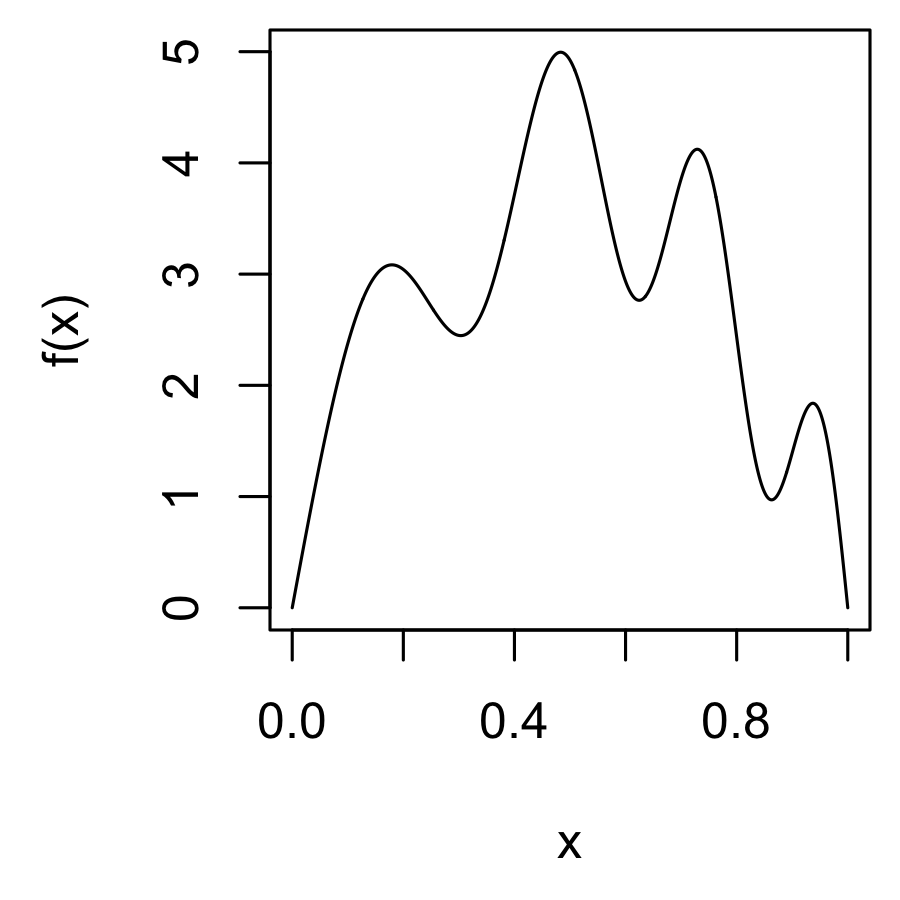

```r
expr = expression(sin(x * (1 + x) * 7 * pi / 2) + (1 - 4 * (x - 0.5)^2) * 4)
f = function(x) eval(expr)
curve(f, n = 1000)
```

As usual, we can compute derivatives using `D()`. Below, we show how to compute its discrete derivatives based on evaluating `f` at 100 design points `xd`, and multiplying these evaluations the discrete difference operator defined over the design points. This is done using the function [d_mat_mult()]. We’ll demonstrate this with both first and second derivatives.

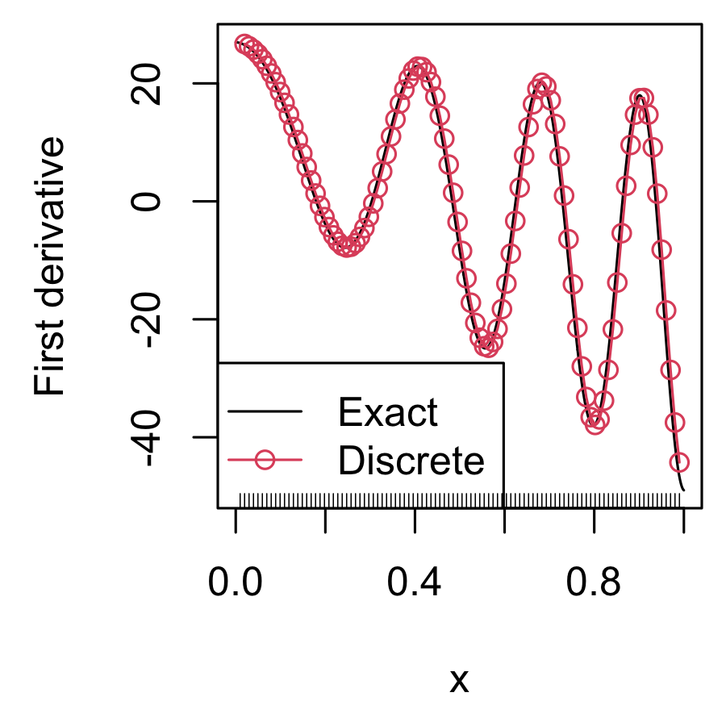

```r
n = 100
xd = 1:n / (n+1)
x = seq(0, 1, length = 1000)

# First derivatives
fd = D(expr, "x")
u1 = as.numeric(eval(fd))
vhat1 = d_mat_mult(f(xd), 1, xd)

plot(x, u1, type = "l", ylab = "First derivative")
points(xd[2:n], vhat1, col = 2, type = "o")
legend("bottomleft", lty = 1, pch = c(NA, 21), col = 1:2,
       legend = c("Exact", "Discrete"))
rug(xd)
```

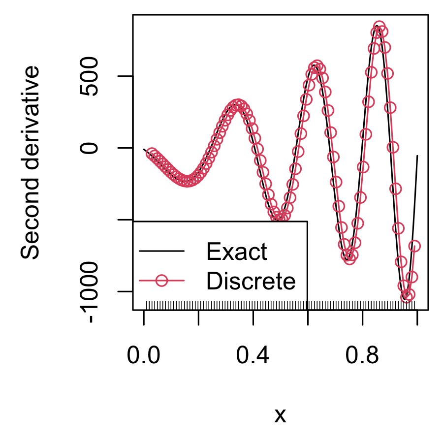

```r
# Second derivatives
fd2 = D(fd, "x")
u2 = as.numeric(eval(fd2))
v2 = d_mat_mult(f(xd), 2, xd)

plot(x, u2, type = "l", ylab = "Second derivative")
points(xd[3:n], v2, col = 2, type = "o")
legend("bottomleft", legend = c("Exact", "Discrete"),
       lty = 1, pch = c(NA, 21), col = 1:2)
rug(xd)
```

As an alternative to [d_mat_mult()], we could form the difference operator (as a sparse matrix) using [d_mat()], and then do the matrix multiplication manually, but using [d_mat_mult()] is more efficient. It doesn’t actually form any such matrix internally, and instead performs a specialized routine to carry out the discrete derivative computations.

## Discrete spline smoothing

Now we’ll smooth some noisy data, by regressing it onto the space of discrete splines of cubic degree, with 9 knots which are roughly evenly-spaced among the design points. This is done using the function [dspline_solve()].

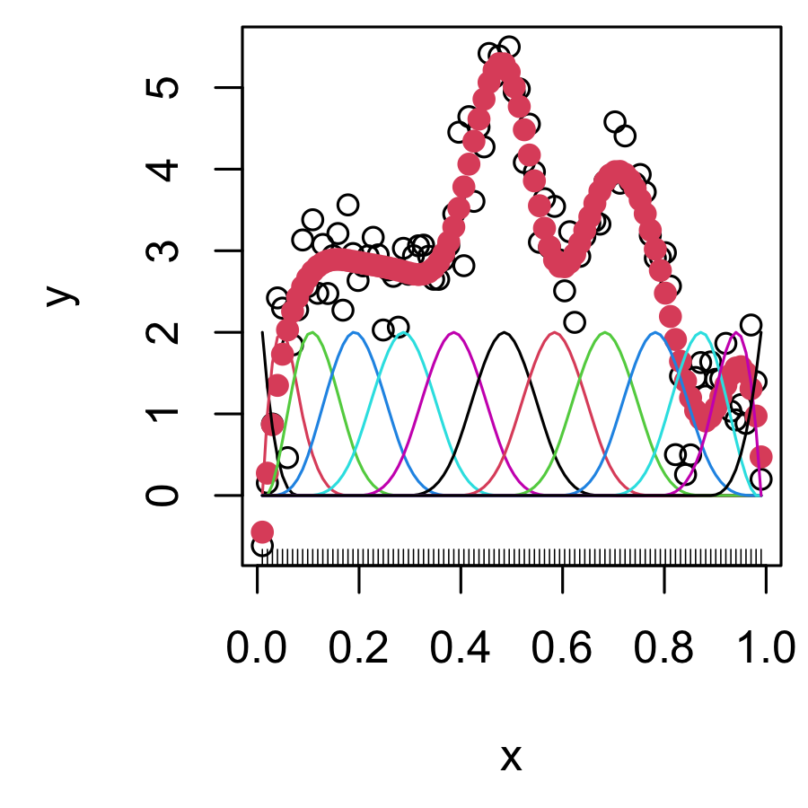

```r
y = f(xd) + rnorm(n, sd = 0.5)

knot_idx = 1:9 * 10
res = dspline_solve(y, 3, xd, knot_idx)
yhat = res$fit # Fitted values from the regression of y onto discrete splines
N = res$mat # Discrete B-spline basis, for visualization purposes only!

plot(xd, y, xlab = "x")
points(xd, yhat, col = 2, pch = 19)
matplot(xd, N * 2, type = "l", lty = 1, add = TRUE)
rug(xd)
```

### Relation to trend filtering

The smoothing above is done using ordinary least squares regression, with fixed knots and without regularization. A related and more advanced technique would be to use trend filtering, which places a knot at each eligible design point (rather than fixing the knots ahead of time) and performs a regularized regression onto the space of discrete splines, by penalizing the $\ell_1$ norm of discrete derivatives across the design points. This has the advantage of being more locally adaptive: allocating more flexibility to the fitted function dynamically, at parts of the input space in which such flexibility is warranted, rather than letting this be dictated by a given fixed knot sequence. To learn more, see the trendfilter package, or [Tibshirani (2014)](https://www.stat.berkeley.edu/~ryantibs/papers/trendfilter.pdf) or Sections 1 and 2.5 of [Tibshirani (2020)](https://www.stat.berkeley.edu/~ryantibs/papers/dspline.pdf).

## Discrete spline interpolation

To go from a sequence of fitted values to a fitted function, we must interpolate in the space of cubic discrete splines. We’ll do this using [dspline_interp()].

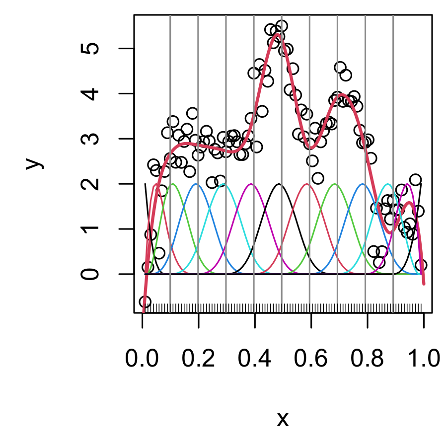

```r
x = seq(0, 1, length = 1000)
fhat = dspline_interp(yhat, 3, xd, x, implicit = FALSE)

plot(xd, y, xlab = "x")
lines(x, fhat, col = 2, lwd = 2)
matplot(xd, N * 2, type = "l", lty = 1, add = TRUE)
abline(v = xd[knot_idx], col = 8)
rug(xd)
```

The function plotted in as a thick red line above is a bona fide cubic discrete spline: it is a piecewise cubic polynomial with knots at the specified points (marked as vertical gray lines), and its discrete derivatives of orders 1 and 2 are all continuous at the knots. This visualized below.

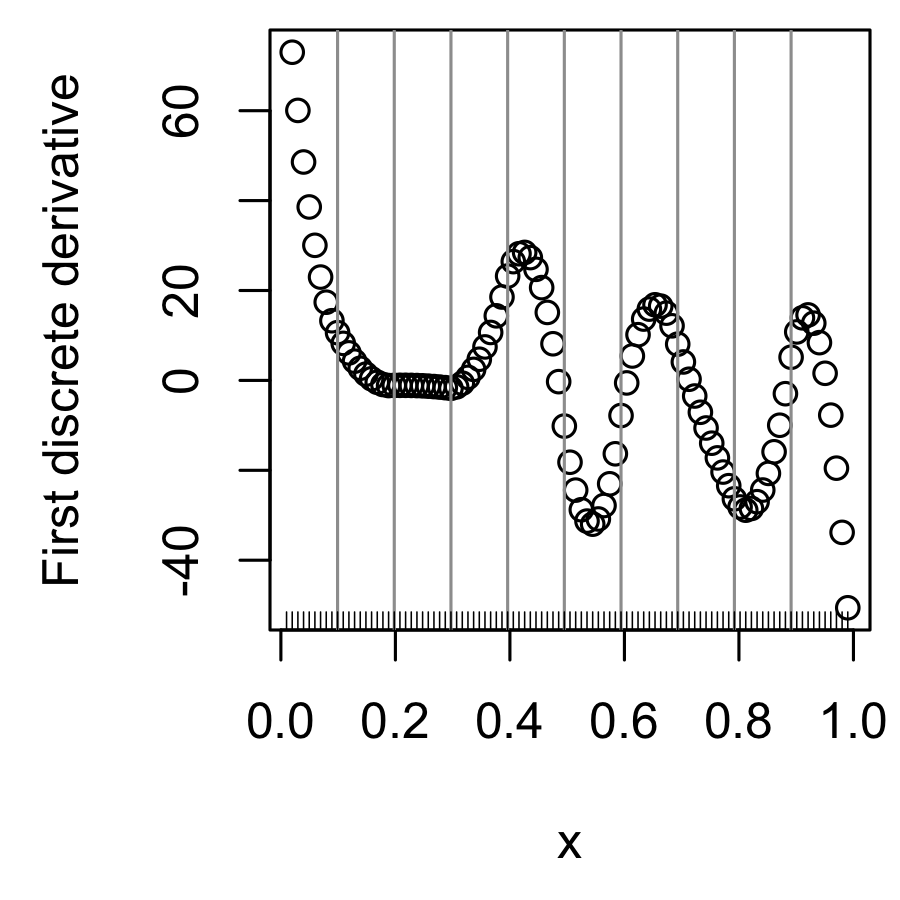

```r
dd1 = d_mat_mult(yhat, 1, xd)
dd2 = d_mat_mult(yhat, 2, xd)

plot(xd[2:n], dd1, xlab = "x", ylab = "First discrete derivative")
abline(v = xd[knot_idx], col = 8)
rug(xd)
```

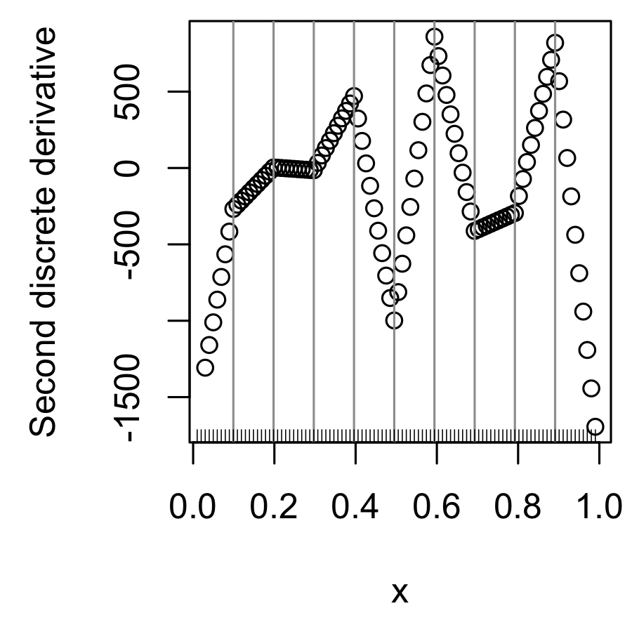

```r
plot(xd[3:n], dd2, xlab = "x", ylab = "Second discrete derivative")
abline(v = xd[knot_idx], col = 8)
rug(xd)
```

## Matching derivatives

What about the discrete derivatives of order 3? Being a cubic discrete spline  
(piecewise cubic polynomial), these are, unsurprisingly, piecewise constant.

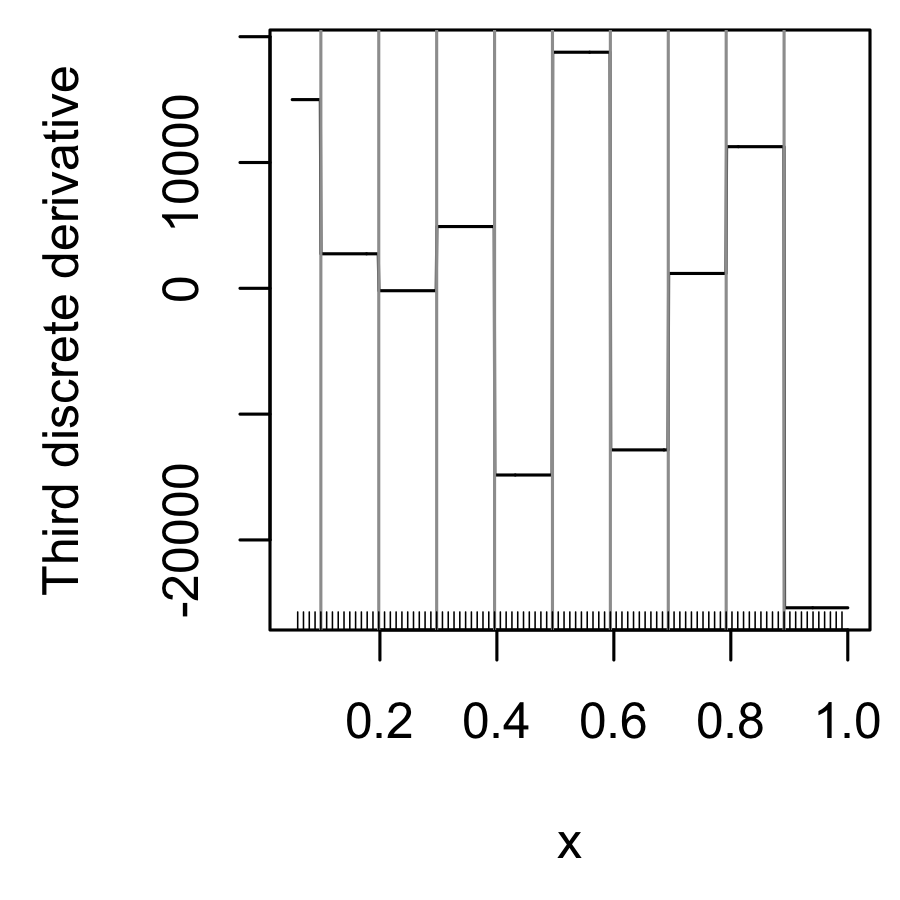

```r
inds = x > 0.05 # Exclude points near left boundary
x = x[inds]
fhat = fhat[inds]
dd3 = discrete_deriv(c(yhat, fhat), 3, xd, x)

plot(x, dd3, type = "l", ylab = "Third discrete derivative")
abline(v = xd[knot_idx], col = 8)
rug(xd[xd > min(x)])
```

Here we used [discrete_deriv()] to compute the discrete derivatives over a fine grid of locations `x` outside of the design points `xd`. (Note: as used earlier, the function [d_mat_mult()] is a convenient way to compute discrete derivatives at the design points `xd` themselves.)

A special property of a `k`th degree discrete spline is that their `k`th degree discrete derivatives match their `k`th derivatives, everywhere in the domain. To check this, we’ll need to first compute an analytic representation for the discrete cubic spline interpolant underlying `fhat`, and then differentiate it using `D()`. For this analytic representation, it is most convenient to use the falling factorial (rather than discrete B-spline) basis.

*Warning: what happens below to compute and evaluate symbolic derivatives of the analytic representation gets a bit hairy! Importantly, you’ll never have to do this in order to use the `dspline` package. It’s only done for the purpose of verifying the claim that the discrete derivatives match the usual derivatives.*

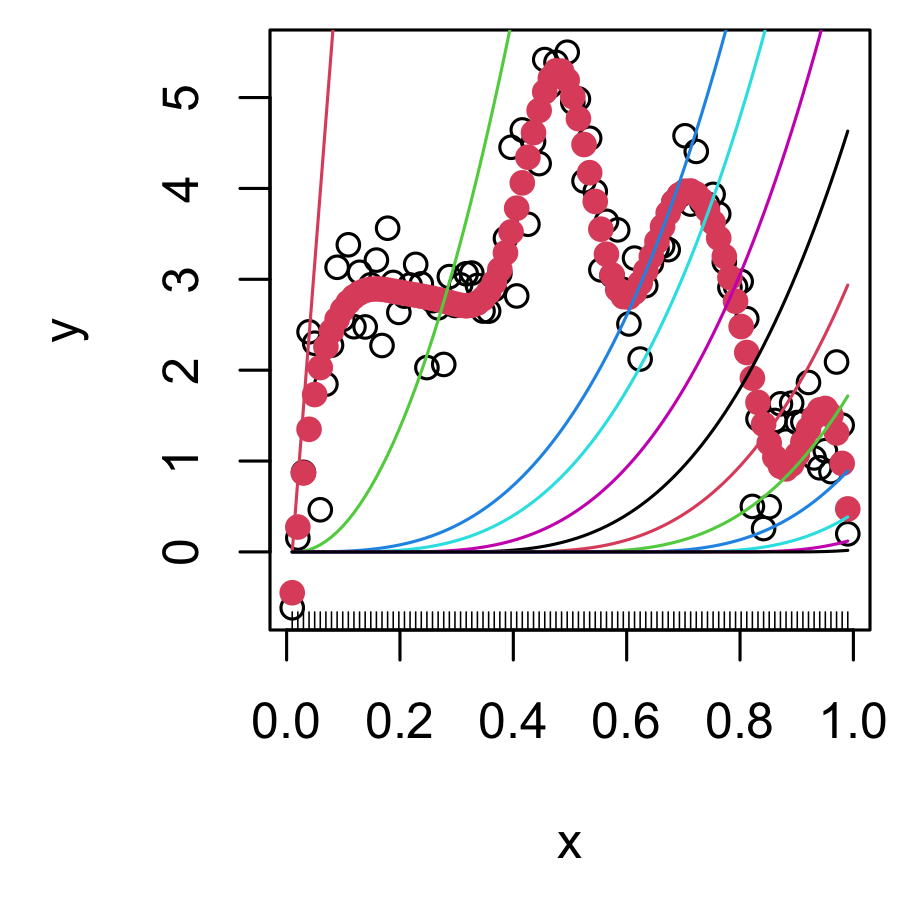

```r
res = dspline_solve(y, 3, xd, knot_idx, basis = "H")
yhat = res$fit # Fitted values from the regression of y onto discrete splines
H = res$mat # Falling factorial basis, for visualization purposes only!
sol = res$sol # Falling factorial basis coefficients, for expansion later

# Sanity check: the fitted values from H (instead of N) should look as before
plot(xd, y, xlab = "x")
points(xd, yhat, col = 2, pch = 19)
matplot(xd, H * 80, type = "l", lty = 1, add = TRUE)
rug(xd)
```

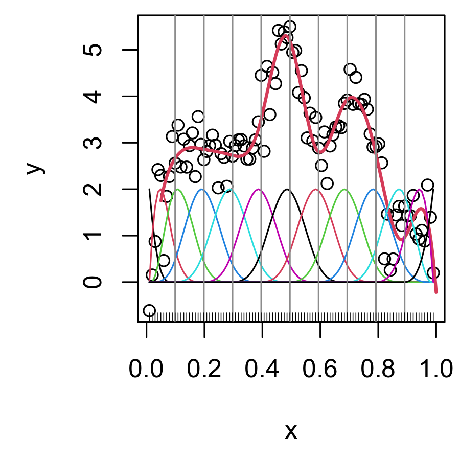

```r
# Now build analytic expansion in terms of falling factorial bases functions.
# Unfortunately we need to separate out the terms involving inequalities, since
# D() can't properly (symbolically) differentiate through inequalities, so this
# ends up being more complicated than it should be ...
poly_terms = sprintf("%f", sol[1])
ineq_terms = "1"
for (j in 2:length(sol)) {
  if (j <= 4) {
    x_prod = paste(
      sprintf("(x - %f)", xd[1:(j-1)]),
      collapse = " * ")
    poly_terms = c(
      poly_terms,
      sprintf("%f * %s / factorial(%i)", sol[j], x_prod, j-1))
    ineq_terms = c(ineq_terms, "1")
  }
  else {
    x_prod = paste(
      sprintf("(x - %f)", xd[knot_idx[j-4] - 2:0]),
      collapse = " * ")
    poly_terms = c(
      poly_terms,
      sprintf("%f * %s / factorial(3)", sol[j], x_prod))
    ineq_terms = c(
      ineq_terms,
      sprintf("(x > %f)", xd[knot_idx[j-4]]))
  }
}

# Sanity check: the interpolant from this expression should look as before
combined_terms = paste(
  paste(poly_terms, ineq_terms, sep = " * "),
  collapse = " + ")
fhat = eval(str2expression(combined_terms))
plot(xd, y, xlab = "x")
lines(x, fhat, col = 2, lwd = 2)
matplot(xd, N * 2, type = "l", lty = 1, add = TRUE)
abline(v = xd[knot_idx], col = 8)
rug(xd)
```

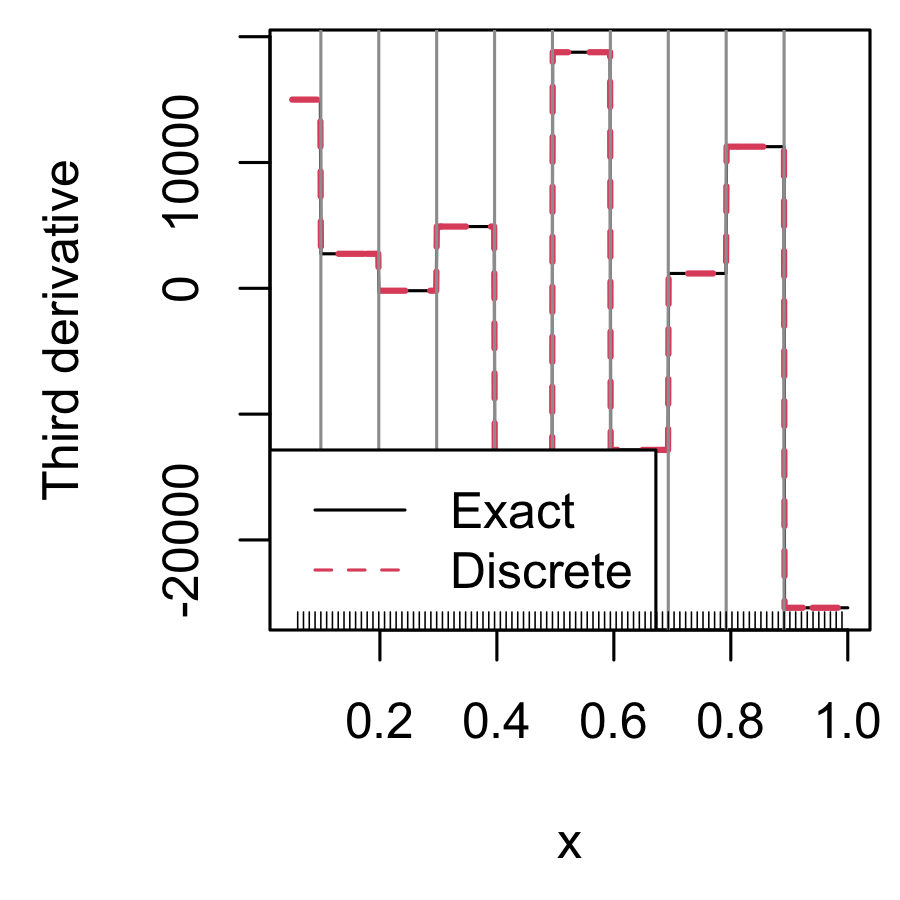

```r
# Higher-order symbolic derivative function (from help file for D())
DD = function(expr, name, order = 1) {
   if(order == 1) D(expr, name)
   else DD(D(expr, name), name, order - 1)
}

# Finally, compute third derivatives of falling factorial basis expansion
d3 = numeric(length(x))
for (i in 1:length(x)) {
  if (x[i] <= xd[knot_idx[1]]) {
    expr = str2expression(paste(poly_terms[1:4], collapse = " + "))
  }
  else {
    j = max(which(x[i] > xd[knot_idx])) + 4
    expr = str2expression(paste(poly_terms[1:j], collapse = " + "))
  }
  d3[i] = eval(DD(expr, "x", 3), list(x = x[i]))
}

plot(x, d3, type = "l", ylab = "Third derivative")
lines(x, dd3, col = 2, lty = 2, lwd = 2)
abline(v = xd[knot_idx], col = 8)
legend("bottomleft", lty = 1:2, col = 1:2,
       legend = c("Exact", "Discrete"))
rug(xd[xd > min(x)])
```